# PA1_template

## Loading and Preprocessing the data

### Loading

- The data is unzipped
- It is extracted
- activity.csv is then opened

```r
data<-read.csv("activity.csv")
str(data)
```

```
## 'data.frame':    17568 obs. of  3 variables:
##  $ steps   : int  NA NA NA NA NA NA NA NA NA NA ...
##  $ date    : Factor w/ 61 levels "2012-10-01","2012-10-02",..: 1 1 1 1 1 1 1 1 1 1 ...
##  $ interval: int  0 5 10 15 20 25 30 35 40 45 ...
```

### Processing

The date column is in ‘factor’ class. So it is converted to ‘Date’ class.

```r
data$date<-as.Date(data$date)
str(data)
```

```
## 'data.frame':    17568 obs. of  3 variables:
##  $ steps   : int  NA NA NA NA NA NA NA NA NA NA ...
##  $ date    : Date, format: "2012-10-01" "2012-10-01" ...
##  $ interval: int  0 5 10 15 20 25 30 35 40 45 ...
```

Now it is perfectly fine.

## What is mean total number of steps taken per day?

### Total number of steps

First the total number of steps for each day is calculated. The code is given below:

```r
totsteps<-aggregate(steps~date,data,FUN = sum,na.rm=TRUE)
head(totsteps)
```

```
##         date steps
## 1 2012-10-02   126
## 2 2012-10-03 11352
## 3 2012-10-04 12116
## 4 2012-10-05 13294
## 5 2012-10-06 15420
## 6 2012-10-07 11015
```

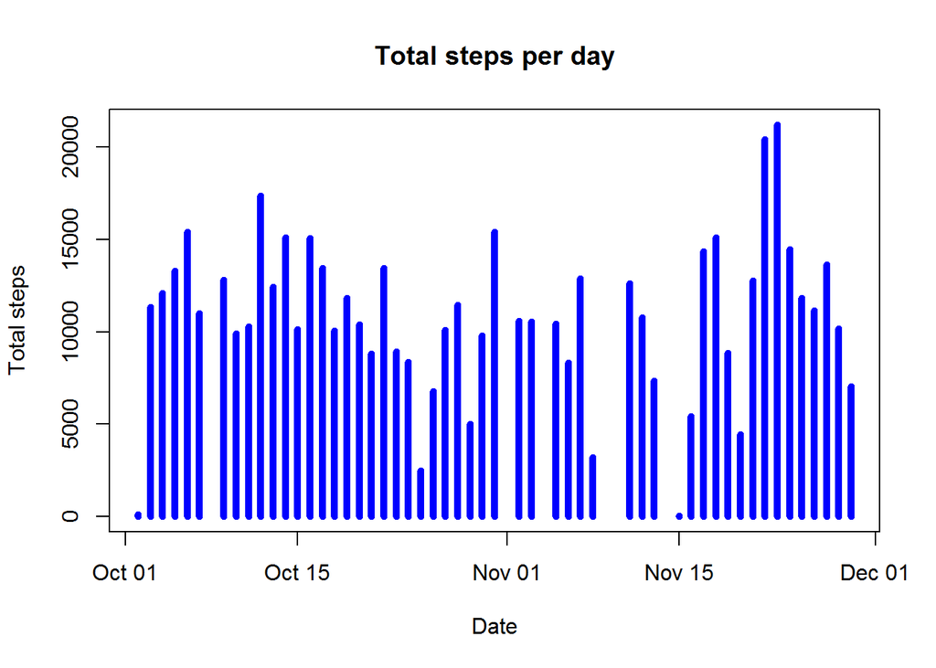

```r
plot(totsteps,type = "h",lwd=5,col="blue",xlab = "Date",ylab = "Total steps",main = "Total steps per day")
```

```r
summary(totsteps$steps)
```

```
##    Min. 1st Qu.  Median    Mean 3rd Qu.    Max.
##      41    8841   10765   10766   13294   21194
```

```r
##The mean is
mean(totsteps$steps)
```

```
## [1] 10766.19
```

```r
##The median is
median(totsteps$steps)
```

```
## [1] 10765
```

Thus we get that the mean and median.

## What is the average daily activity pattern?

The mean of the steps is found out for the 5 minute interval of all the days.

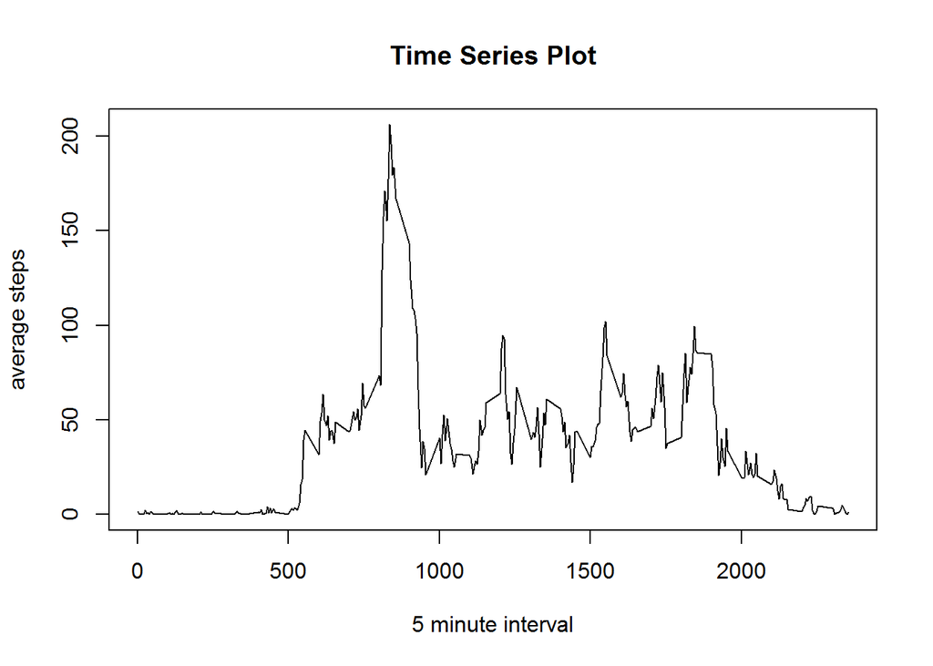

```r
activ<-aggregate(steps~interval,data=data,na.rm=TRUE,FUN = mean)
plot(activ,type="l",xlab = "5 minute interval",ylab = "average steps",main = "Time Series Plot")
```

Thus the required plot is obtained.

Maximum Number of average steps is found out from the dataset activ. Then the corresponding interval.

```r
maxstep<-max(activ$steps)
activ[which(activ$steps==maxstep),]
```

```
##     interval    steps
## 104      835 206.1698
```

```r
activ[which(activ$steps==maxstep),]$interval
```

```
## [1] 835
```

The interval for maximum average steps is thus found.

## Imputing missing values

### Number of missing values

First the NA positions are located .Then the position are counted.

```r
napos<-is.na(data$steps)
sum(napos)
```

```
## [1] 2304
```

Hence it is calculated.

A vector of the mean steps for an interval is made.

```r
means<-activ$steps[match(activ$interval,data$interval)]
```

```r
## A new dataset is created which is a copy of the old data set
newdata<-data
newdata$steps[is.na(data$steps)]=means[which(is.na(data$steps))]
head(newdata)
```

```
##       steps       date interval
## 1 1.7169811 2012-10-01        0
## 2 0.3396226 2012-10-01        5
## 3 0.1320755 2012-10-01       10
## 4 0.1509434 2012-10-01       15
## 5 0.0754717 2012-10-01       20
## 6 2.0943396 2012-10-01       25
```

### Variation from the original dataset

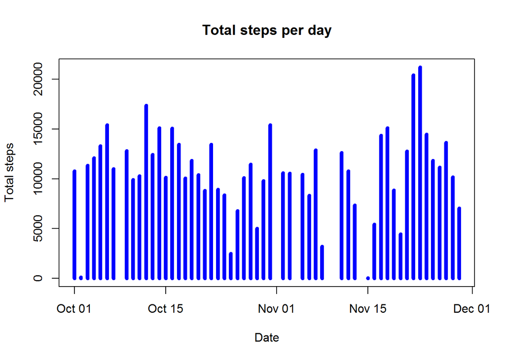

```r
newtot<-aggregate(steps~date,newdata,FUN = sum)
plot(newtot,type = "h",lwd=5,col="blue",xlab = "Date",ylab = "Total steps",main = "Total steps per day")
```

```r
summary(newtot$steps)
```

```
##    Min. 1st Qu.  Median    Mean 3rd Qu.    Max.
##      41    8860   10766   10766   13191   21194
```

```r
##The mean is
mean(newtot$steps)
```

```
## [1] 10766.19
```

```r
##The median is
median(newtot$steps)
```

```
## [1] 10765.59
```

```r
##Variation of mean and median
## mean variation
mean(totsteps$steps)-mean(newtot$steps)
```

```
## [1] 0
```

```r
## median variation
median(totsteps$steps)-median(newtot$steps)
```

```
## [1] -0.5943396
```

Thus it is found out that the mean for the newdata set remains the same. But the median shifts more towards the mean.If we round off the values of both mean and median we find that they are same. Thus inputing the NA values gives us a distinct central tendency.

## Are there differences in activity patterns between weekdays and weekends?

### Creating a column of factors of weekdays and weekends based on date

Using the weekdays() function the weekday of the date is calculated and based on whether it is a weekday or weekend thw column is made.

```r
newdata$day<-sapply(newdata$date, function(x){if (weekdays(x)=="Monday" |  weekdays(x)=="Tuesday"|weekdays(x)=="Wednesday"| weekdays(x)=="Thursday" | weekdays(x)=="Friday") {y<-"Weekday"} else {y<-"Weekend"};y})
newdata$day<-as.factor(newdata$day)
head(newdata)
```

```
##       steps       date interval     day
## 1 1.7169811 2012-10-01        0 Weekday
## 2 0.3396226 2012-10-01        5 Weekday
## 3 0.1320755 2012-10-01       10 Weekday
## 4 0.1509434 2012-10-01       15 Weekday
## 5 0.0754717 2012-10-01       20 Weekday
## 6 2.0943396 2012-10-01       25 Weekday
```

### Plotting average steps based on daytype

First the data is aggregated based on day in a new data set daytype and finally the graph is plotted.

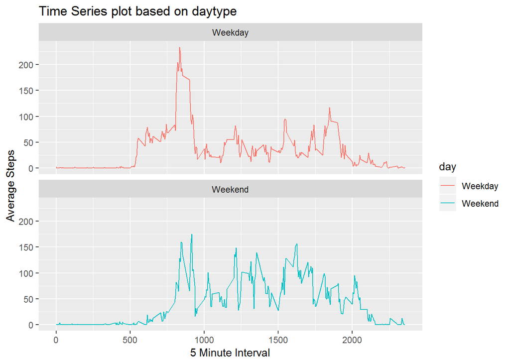

```r
library(ggplot2)
daytype<-aggregate(steps~interval+day,data = newdata,FUN = mean)
g<-ggplot(daytype,aes(interval,steps))+geom_line(aes(color=day))+facet_wrap(.~day,ncol = 1,nrow = 2)+labs(x="5 Minute Interval",y="Average Steps",title="Time Series plot based on daytype")
print(g)
```